# Practical Machine Learning Project Write_Up

Andria Hall

Sunday, October 25, 2015

### Background

This project write-up is to build a machine learning model based on a group of enthusiasts who take measurements about themselves regularly to improve their health. This data comes from accelerometers on the belt, forearm, arm and dumbell of **six** participants who were asked to perform barbell lifts correctly and incorrectly in five different ways.

### Reproduceability

We will load the appropriate packages and set the seed for reproduceable results.

```r
library(randomForest)
library(parallel)
library(doParallel)
library(rattle)
```

```r
library(rpart.plot)
```

We will now import the testing data and the training data and test for identicality.

```r
library(data.table)

# Load the training data set
setInternet2(TRUE)

# Load the training data set
url <- "https://d396qusza40orc.cloudfront.net/predmachlearn/pml-training.csv"
DTrain <- fread(url)
```

```
##
Read 51.0% of 19622 rows
Read 19622 rows and 160 (of 160) columns from 0.011 GB file in 00:00:04
```

```r
trainColnames <- colnames(DTrain)

# Load the testing data set
url <- "https://d396qusza40orc.cloudfront.net/predmachlearn/pml-testing.csv"
DTest <- fread(url)
testColnames <- colnames(DTest)

# Verify that the column names (excluding classe and problem_id) are identical in the training and testing set.
all.equal(trainColnames[1:length(trainColnames)-1], testColnames[1:length(trainColnames)-1])
```

```
## [1] TRUE
```

We will now remove all `NA` values and columns: `X`, `user_name`, `raw_timestamp_part_1`, `raw_timestamp_part_2`, `cvtd_timestamp`, `new_window` `num_window` as they are not predictors.

```r
# Discard columns with missing values
DiscardNAs <- sapply(DTest, function (x) any(is.na(x) | x == ""))
isPredictor <- !DiscardNAs & grepl("belt|[^(fore)]arm|dumbbell|forearm", names(DiscardNAs))
predData <- names(DiscardNAs)[isPredictor]
predData
```

```
##  [1] "roll_belt"            "pitch_belt"           "yaw_belt"
##  [4] "total_accel_belt"     "gyros_belt_x"         "gyros_belt_y"
##  [7] "gyros_belt_z"         "accel_belt_x"         "accel_belt_y"
## [10] "accel_belt_z"         "magnet_belt_x"        "magnet_belt_y"
## [13] "magnet_belt_z"        "roll_arm"             "pitch_arm"
## [16] "yaw_arm"              "total_accel_arm"      "gyros_arm_x"
## [19] "gyros_arm_y"          "gyros_arm_z"          "accel_arm_x"
## [22] "accel_arm_y"          "accel_arm_z"          "magnet_arm_x"
## [25] "magnet_arm_y"         "magnet_arm_z"         "roll_dumbbell"
## [28] "pitch_dumbbell"       "yaw_dumbbell"         "total_accel_dumbbell"
## [31] "gyros_dumbbell_x"     "gyros_dumbbell_y"     "gyros_dumbbell_z"
## [34] "accel_dumbbell_x"     "accel_dumbbell_y"     "accel_dumbbell_z"
## [37] "magnet_dumbbell_x"    "magnet_dumbbell_y"    "magnet_dumbbell_z"
## [40] "roll_forearm"         "pitch_forearm"        "yaw_forearm"
## [43] "total_accel_forearm"  "gyros_forearm_x"      "gyros_forearm_y"
## [46] "gyros_forearm_z"      "accel_forearm_x"      "accel_forearm_y"
## [49] "accel_forearm_z"      "magnet_forearm_x"     "magnet_forearm_y"
## [52] "magnet_forearm_z"
```

We will now subset the predData to include only the predictors and the outcome variable, `classe`.

```r
# Subset predData dataset
predDataClasse <- c("classe", predData)
DTrain <- DTrain[, predDataClasse, with=FALSE]
dim(DTrain)
```

```
## [1] 19622    53
```

```r
names(DTrain)
```

```
##  [1] "classe"               "roll_belt"            "pitch_belt"
##  [4] "yaw_belt"             "total_accel_belt"     "gyros_belt_x"
##  [7] "gyros_belt_y"         "gyros_belt_z"         "accel_belt_x"
## [10] "accel_belt_y"         "accel_belt_z"         "magnet_belt_x"
## [13] "magnet_belt_y"        "magnet_belt_z"        "roll_arm"
## [16] "pitch_arm"            "yaw_arm"              "total_accel_arm"
## [19] "gyros_arm_x"          "gyros_arm_y"          "gyros_arm_z"
## [22] "accel_arm_x"          "accel_arm_y"          "accel_arm_z"
## [25] "magnet_arm_x"         "magnet_arm_y"         "magnet_arm_z"
## [28] "roll_dumbbell"        "pitch_dumbbell"       "yaw_dumbbell"
## [31] "total_accel_dumbbell" "gyros_dumbbell_x"     "gyros_dumbbell_y"
## [34] "gyros_dumbbell_z"     "accel_dumbbell_x"     "accel_dumbbell_y"
## [37] "accel_dumbbell_z"     "magnet_dumbbell_x"    "magnet_dumbbell_y"
## [40] "magnet_dumbbell_z"    "roll_forearm"         "pitch_forearm"
## [43] "yaw_forearm"          "total_accel_forearm"  "gyros_forearm_x"
## [46] "gyros_forearm_y"      "gyros_forearm_z"      "accel_forearm_x"
## [49] "accel_forearm_y"      "accel_forearm_z"      "magnet_forearm_x"
## [52] "magnet_forearm_y"     "magnet_forearm_z"
```

and make `classe` a factor.

```r
DTrain <- DTrain[, classe := factor(DTrain[, classe])]
DTrain[, .N, classe]
```

```
##    classe    N
## 1:      A 5580
## 2:      B 3797
## 3:      C 3422
## 4:      D 3216
## 5:      E 3607
```

We will next Split the DTrain into 60% training and 40% testing dataset.

```r
library(caret)
set.seed(12345)
trainIndex <- createDataPartition(DTrain$classe, p=0.6)
trainData <- DTrain[trainIndex[[1]]]
testData <- DTrain[-trainIndex[[1]]]
```

Preprocess the prediction variables by centering and scaling.

```r
X <- trainData[, predData, with=FALSE]
preProc <- preProcess(X)
preProc
```

```
##
## Call:
## preProcess.default(x = X)
##
## Created from 11776 samples and 52 variables
## Pre-processing: centered, scaled
```

```r
XCS <- predict(preProc, X)
DTrainCS <- data.table(data.frame(classe = trainData[, classe], XCS))
```

Apply the centering and scaling to the probing dataset.

```r
X <- testData[, predData, with=FALSE]
XCS <- predict(preProc, X)
DProbeCS <- data.table(data.frame(classe = testData[, classe], XCS))
```

We will check for covariates that have near zero variance

```r
nzv <- nearZeroVar(DTrain, saveMetrics=TRUE)
if (any(nzv$nzv)) nzv else message("No variables with near zero variance")
```

```
## No variables with near zero variance
```

Training the dataset using random forest algorithm

```r
# Configure the train control for cross-validation

cl <- makeCluster(detectCores() -1)
registerDoParallel(cl)

tctrl <- trainControl(classProbs=TRUE, savePredictions=TRUE, allowParallel = TRUE)

# Fit the model using Random Forests algorithm
Fitmod <- randomForest(classe ~.,  data = DTrainCS,
                method="rf")
stopCluster(cl)
```

```r
print(Fitmod)
```

```
##
## Call:
##  randomForest(formula = classe ~ ., data = DTrainCS, method = "rf")
##                Type of random forest: classification
##                      Number of trees: 500
## No. of variables tried at each split: 7
##
##         OOB estimate of  error rate: 0.71%
## Confusion matrix:
##      A    B    C    D    E  class.error
## A 3345    3    0    0    0 0.0008960573
## B   15 2253   11    0    0 0.0114085125
## C    0   11 2039    4    0 0.0073028238
## D    0    0   24 1902    4 0.0145077720
## E    0    1    2    9 2153 0.0055427252
```

### Evaluate the model on the training dataset

```r
pred <- predict(Fitmod, DTrainCS)
confusionMatrix(pred, DTrainCS[, classe])
```

```
## Confusion Matrix and Statistics
##
##           Reference
## Prediction    A    B    C    D    E
##          A 3348    0    0    0    0
##          B    0 2279    0    0    0
##          C    0    0 2054    0    0
##          D    0    0    0 1930    0
##          E    0    0    0    0 2165
##
## Overall Statistics
##
##                Accuracy : 1
##                  95% CI : (0.9997, 1)
##     No Information Rate : 0.2843
##     P-Value [Acc > NIR] : < 2.2e-16
##
##                   Kappa : 1
##  Mcnemar's Test P-Value : NA
##
## Statistics by Class:
##
##                      Class: A Class: B Class: C Class: D Class: E
## Sensitivity            1.0000   1.0000   1.0000   1.0000   1.0000
## Specificity            1.0000   1.0000   1.0000   1.0000   1.0000
## Pos Pred Value         1.0000   1.0000   1.0000   1.0000   1.0000
## Neg Pred Value         1.0000   1.0000   1.0000   1.0000   1.0000
## Prevalence             0.2843   0.1935   0.1744   0.1639   0.1838
## Detection Rate         0.2843   0.1935   0.1744   0.1639   0.1838
## Detection Prevalence   0.2843   0.1935   0.1744   0.1639   0.1838
## Balanced Accuracy      1.0000   1.0000   1.0000   1.0000   1.0000
```

### Evaluate the model on the testing dataset

```r
pred <- predict(Fitmod, DProbeCS)
confusionMatrix(pred, DProbeCS[, classe])
```

```
## Confusion Matrix and Statistics
##
##           Reference
## Prediction    A    B    C    D    E
##          A 2230    7    0    0    0
##          B    2 1506    7    0    0
##          C    0    5 1361   16    2
##          D    0    0    0 1268    4
##          E    0    0    0    2 1436
##
## Overall Statistics
##
##                Accuracy : 0.9943
##                  95% CI : (0.9923, 0.9958)
##     No Information Rate : 0.2845
##     P-Value [Acc > NIR] : < 2.2e-16
##
##                   Kappa : 0.9927
##  Mcnemar's Test P-Value : NA
##
## Statistics by Class:
##
##                      Class: A Class: B Class: C Class: D Class: E
## Sensitivity            0.9991   0.9921   0.9949   0.9860   0.9958
## Specificity            0.9988   0.9986   0.9964   0.9994   0.9997
## Pos Pred Value         0.9969   0.9941   0.9834   0.9969   0.9986
## Neg Pred Value         0.9996   0.9981   0.9989   0.9973   0.9991
## Prevalence             0.2845   0.1935   0.1744   0.1639   0.1838
## Detection Rate         0.2842   0.1919   0.1735   0.1616   0.1830
## Detection Prevalence   0.2851   0.1931   0.1764   0.1621   0.1833
## Balanced Accuracy      0.9989   0.9953   0.9957   0.9927   0.9978
```

### Display the final model

```r
varImp(Fitmod)
```

```
##                        Overall
## roll_belt            727.82480
## pitch_belt           428.31809
## yaw_belt             554.78937
## total_accel_belt     135.77689
## gyros_belt_x          58.28922
## gyros_belt_y          72.24594
## gyros_belt_z         195.51297
## accel_belt_x          75.86552
## accel_belt_y          81.21622
## accel_belt_z         266.25319
## magnet_belt_x        148.88583
## magnet_belt_y        228.60075
## magnet_belt_z        241.06039
## roll_arm             185.58435
## pitch_arm             95.90812
## yaw_arm              147.45842
## total_accel_arm       60.94373
## gyros_arm_x           78.61947
## gyros_arm_y           77.69289
## gyros_arm_z           35.65819
## accel_arm_x          144.65424
## accel_arm_y           85.39126
## accel_arm_z           83.28439
## magnet_arm_x         144.70874
## magnet_arm_y         137.32706
## magnet_arm_z         111.38072
## roll_dumbbell        238.84253
## pitch_dumbbell       102.04924
## yaw_dumbbell         156.73549
## total_accel_dumbbell 146.65674
## gyros_dumbbell_x      75.36596
## gyros_dumbbell_y     139.36971
## gyros_dumbbell_z      52.84275
## accel_dumbbell_x     161.16630
## accel_dumbbell_y     250.34731
## accel_dumbbell_z     197.03422
## magnet_dumbbell_x    282.60145
## magnet_dumbbell_y    413.44904
## magnet_dumbbell_z    449.94420
## roll_forearm         364.60397
## pitch_forearm        459.46788
## yaw_forearm          105.76826
## total_accel_forearm   67.28882
## gyros_forearm_x       46.47415
## gyros_forearm_y       72.80016
## gyros_forearm_z       50.52314
## accel_forearm_x      203.46203
## accel_forearm_y       88.41923
## accel_forearm_z      144.07287
## magnet_forearm_x     132.48637
## magnet_forearm_y     135.34984
## magnet_forearm_z     170.18141
```

Examine groups of predictable variable

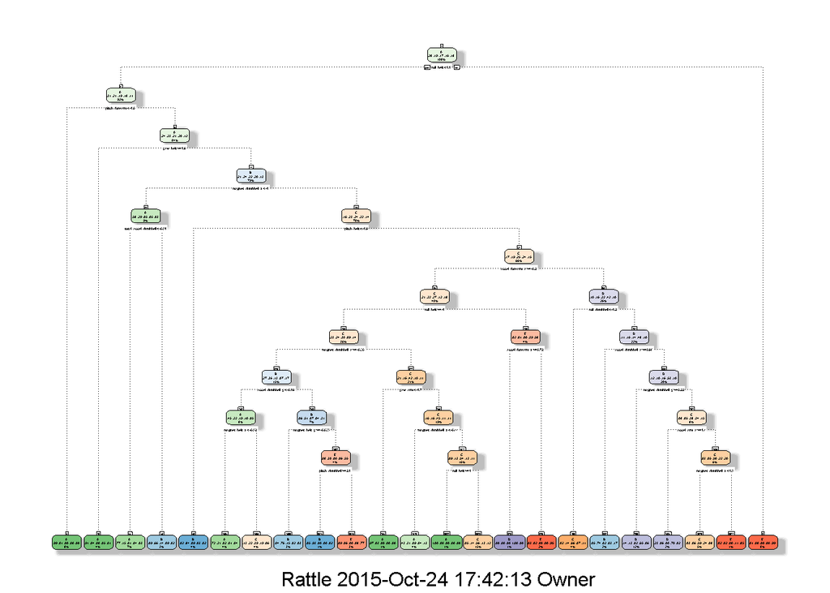

```r
set.seed(12345)
modFit <- rpart(classe ~ ., data=DTrainCS, method="class")

fancyRpartPlot(modFit)
```

Save training model object for later.

```r
save(Fitmod, file="Fitmod.RData")
```

### Predict on the test data

```r
# Load Fitmod data
load(file="Fitmod.RData", verbose=TRUE)
```

```
## Loading objects:
##   Fitmod
```

Get predictions and evaluate

```r
DTestCS <- predict(preProc, DTest[, predData, with=FALSE])
pred <- predict(Fitmod, DTestCS)
DTest <- cbind(pred, DTestCS)
subset(DTest, select=names(DTest)[grep("belt|[^(fore)]arm|dumbell|forearm", names(DTest), invert=TRUE)])
```

```
##    pred roll_dumbbell pitch_dumbbell yaw_dumbbell total_accel_dumbbell
## 1     B    -0.6000208      0.9610056   1.52407132          -0.46620122
## 2     A     0.4343158     -1.1525706  -0.92501603           1.67881953
## 3     B     0.4714511     -1.0901091  -0.92122950           1.48381764
## 4     A     0.2714871     -0.5171219  -1.26254856           0.41130727
## 5     A    -1.7980893     -1.1456364  -0.18064954          -0.95370594
## 6     E     0.5447446     -1.0681539  -0.87167447           1.48381764
## 7     D     0.4567825     -1.1598265  -0.90505624           1.48381764
## 8     B     0.5009245     -1.0882117  -0.89896158           1.48381764
## 9     A     1.4089453      0.2902999   0.41114704          -1.05120688
## 10    A    -1.9375056     -0.5670336   0.37898789          -1.14870783
## 11    B     1.4298579     -0.5714683   0.08744055          -1.24620877
## 12    C     0.3058341     -1.1528776  -1.01648855           1.58131858
## 13    B    -0.1672163      1.2112988   1.45352794          -0.56370217
## 14    A     0.4614317     -1.0524267  -0.94339947           1.58131858
```

[output cut: 69 more lines]

### Write submission files to `pred` in Practical Machine Learning folder

```r
pml_write_files = function(x){
  n = length(x)
    for(i in 1:n){
    filename = paste0("problem_id_",i,".txt")
    write.table(x[i],file=filename,quote=FALSE,row.names=FALSE,col.names=FALSE)
  }
}
pml_write_files(pred)
```